# KSR 2020 Herbivore Ordination

### 2.2.2 Plots

> I don’t see any clear trends yet: herbivore occurrence doesn’t seem to correlate with urbanization (when quantified as distance from the city center OR by urbanization score) NOR does it seem to vary between urban subtransects.

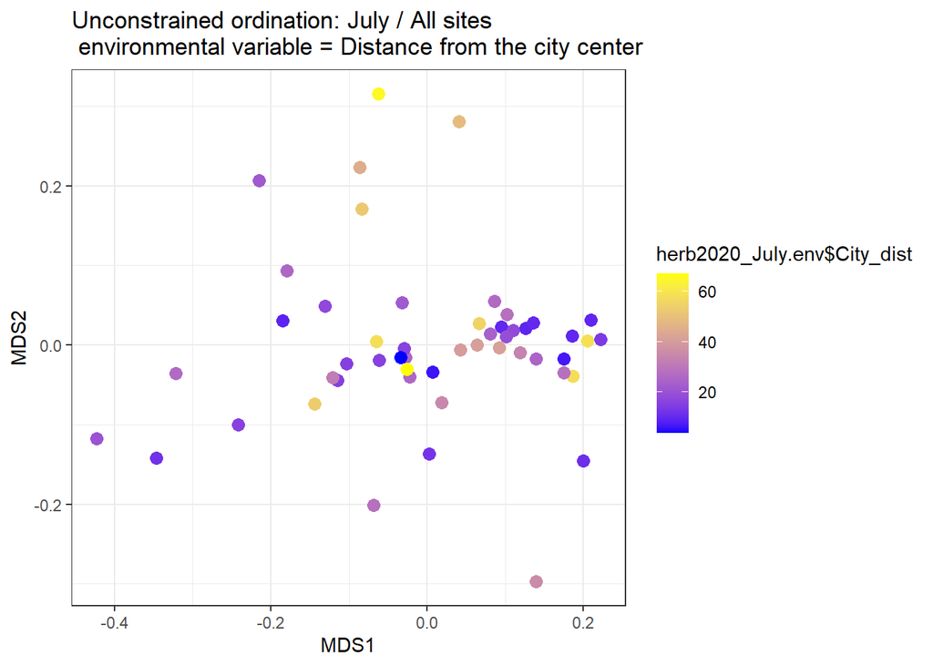

```r
## July
### All sites
ggplot(MDS_xy_J, aes(MDS1, MDS2,
                     col = herb2020_July.env$City_dist)) +
  geom_point(size = 3) +
  theme_bw() +
  ggtitle('Unconstrained ordination: July / All sites \n environmental variable = Distance from the city center') +
  scale_color_gradient(low="blue", high="yellow")
```

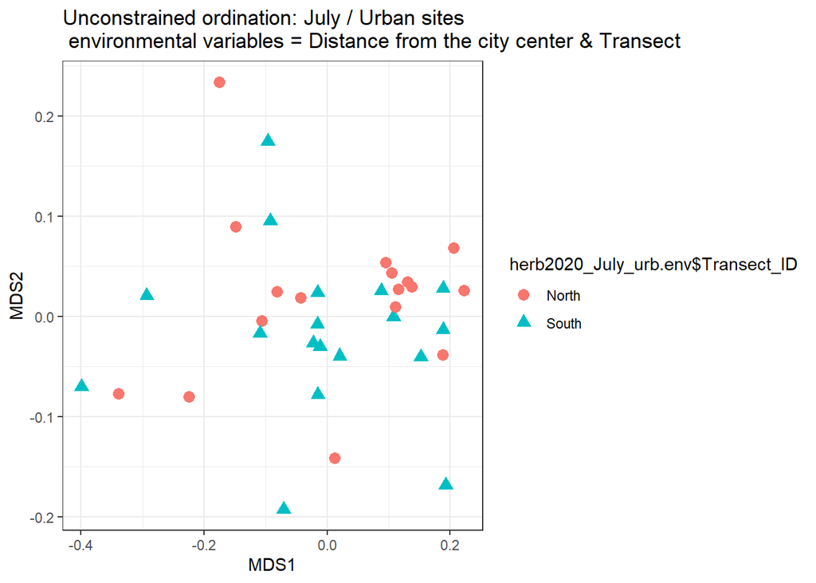

```r
### Just urban sites
ggplot(MDS_xy_J_urb, aes(MDS1, MDS2,
                     col = herb2020_July_urb.env$Transect_ID,
                     shape = herb2020_July_urb.env$Transect_ID)) +
  geom_point(size = 3) +
  theme_bw() +
  ggtitle('Unconstrained ordination: July / Urban sites \n environmental variables = Distance from the city center & Transect')
```

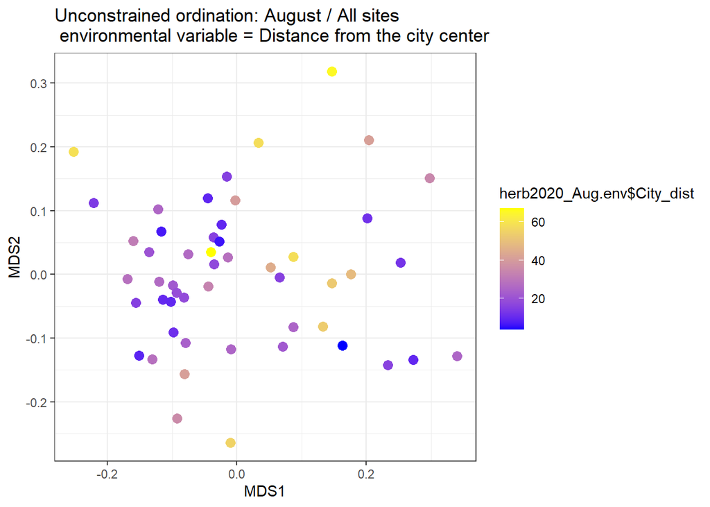

```r
## Aug
### All sites
ggplot(MDS_xy_A, aes(MDS1, MDS2,
                     col = herb2020_Aug.env$City_dist)) +
  geom_point(size = 3) +
  theme_bw() +
  ggtitle('Unconstrained ordination: August / All sites \n environmental variable = Distance from the city center') +
  scale_color_gradient(low="blue", high="yellow")
```

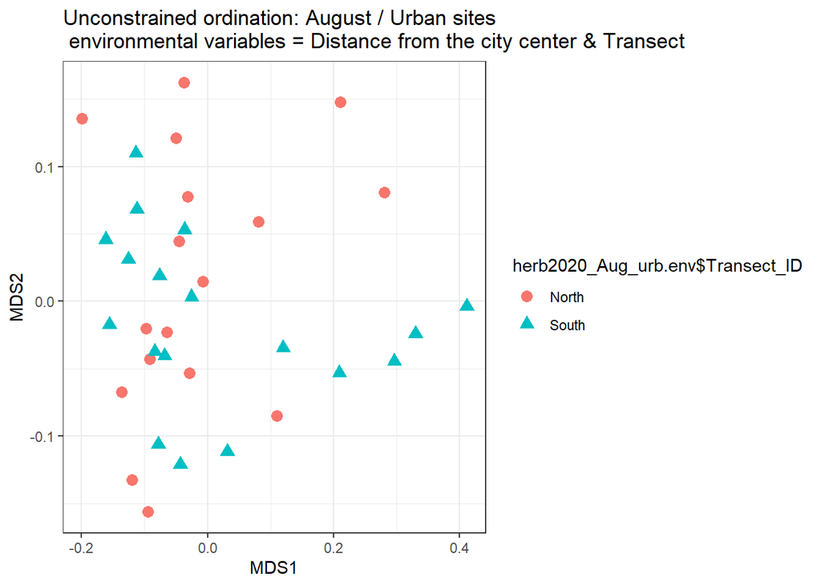

```r
### Just urban sites
ggplot(MDS_xy_A_urb, aes(MDS1, MDS2,
                     col = herb2020_Aug_urb.env$Transect_ID,
                     shape = herb2020_Aug_urb.env$Transect_ID)) +
  geom_point(size = 3) +
  theme_bw() +
  ggtitle('Unconstrained ordination: August / Urban sites \n environmental variables = Distance from the city center & Transect')
```

## 2.3 Constrained ordination (RDA)

### 2.3.1 Pre-plot setup

#### 2.3.1.1 July

```r
### All sites
#### herbivores ~ City_dist
RDA_July <- rda(herb2020_July.hel ~ City_dist,
                              data=herb2020_July.env )
summary(RDA_July)
```

```
##
## Call:
## rda(formula = herb2020_July.hel ~ City_dist, data = herb2020_July.env)
##
## Partitioning of variance:
##               Inertia Proportion
## Total         0.11726    1.00000
## Constrained   0.00206    0.01757
## Unconstrained 0.11520    0.98243
##
## Eigenvalues, and their contribution to the variance
##
## Importance of components:
##                          RDA1     PC1     PC2     PC3      PC4      PC5
## Eigenvalue            0.00206 0.06392 0.01853 0.01485 0.009602 0.002902
## Proportion Explained  0.01757 0.54509 0.15802 0.12662 0.081892 0.024753
## Cumulative Proportion 0.01757 0.56266 0.72068 0.84730 0.929193 0.953946
##                            PC6      PC7      PC8       PC9      PC10
## Eigenvalue            0.002032 0.001624 0.001011 0.0004443 0.0002887
## Proportion Explained  0.017330 0.013854 0.008620 0.0037890 0.0024620
## Cumulative Proportion 0.971275 0.985129 0.993749 0.9975380 1.0000000
##
## Accumulated constrained eigenvalues
## Importance of components:
##                          RDA1
## Eigenvalue            0.00206
## Proportion Explained  1.00000
## Cumulative Proportion 1.00000
##
## Scaling 2 for species and site scores
## * Species are scaled proportional to eigenvalues
## * Sites are unscaled: weighted dispersion equal on all dimensions
## * General scaling constant of scores:  1.556062
##
##
## Species scores
##
##                                     RDA1       PC1       PC2       PC3
## mean_Monarch_Quantity_Past      0.000000  0.000000  0.000000  0.000000
## mean_Monarch_Quantity_Observed -0.025631 -0.124046  0.001925 -0.059322
```

[output cut: 124 more lines]

```
## row43 -0.107866 -0.165109 -0.0282191 -0.053634 -0.05490  0.11238
## row44 -0.070164  0.210131  0.7470476  0.135698 -0.09051  0.31987
## row45 -0.012082 -0.113224  0.0569333 -0.071665 -0.10549  0.15794
## row46  0.006960 -0.129222 -0.0492042 -0.105668 -0.11165  0.04394
## row47  0.007128  0.093241 -0.0866650 -0.002205  0.73340  0.33392
## row48  0.007481 -0.273543 -0.0384045 -0.018779 -0.01429 -0.24938
## row49 -0.046448 -0.111782 -0.0474297 -0.101470 -0.10051  0.11216
## row50 -0.089864  0.610841  0.0190148 -0.105279 -0.04589 -0.18931
## row51 -0.128967  0.111896 -0.1945262  0.406367 -0.21336  0.11435
##
##
## Biplot scores for constraining variables
##
##           RDA1 PC1 PC2 PC3 PC4 PC5
## City_dist    1   0   0   0   0   0
```

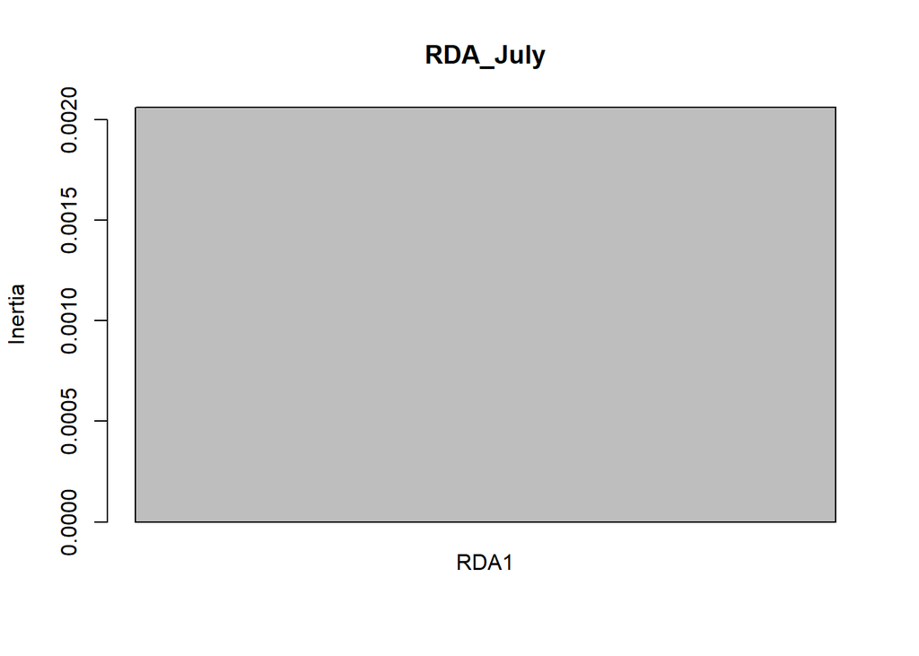

```r
screeplot(RDA_July)
```

```r
#### herbivores ~ Urb_score
RDA_July_urbscore <- rda(herb2020_July.hel ~ Urb_score,
                              data = herb2020_July.env )
summary(RDA_July_urbscore)
```

```
##
## Call:
## rda(formula = herb2020_July.hel ~ Urb_score, data = herb2020_July.env)
##
## Partitioning of variance:
##                Inertia Proportion
## Total         0.117257    1.00000
## Constrained   0.002457    0.02095
## Unconstrained 0.114800    0.97905
##
## Eigenvalues, and their contribution to the variance
##
## Importance of components:
##                           RDA1     PC1    PC2     PC3      PC4      PC5
## Eigenvalue            0.002457 0.06373 0.0186 0.01453 0.009511 0.002908
## Proportion Explained  0.020950 0.54352 0.1586 0.12389 0.081114 0.024802
## Cumulative Proportion 0.020950 0.56447 0.7231 0.84702 0.928130 0.952932
##                            PC6      PC7      PC8       PC9      PC10
## Eigenvalue            0.002131 0.001631 0.001014 0.0004517 0.0002913
## Proportion Explained  0.018174 0.013911 0.008647 0.0038523 0.0024839
## Cumulative Proportion 0.971106 0.985017 0.993664 0.9975161 1.0000000
##
## Accumulated constrained eigenvalues
## Importance of components:
##                           RDA1
## Eigenvalue            0.002457
## Proportion Explained  1.000000
## Cumulative Proportion 1.000000
##
## Scaling 2 for species and site scores
## * Species are scaled proportional to eigenvalues
## * Sites are unscaled: weighted dispersion equal on all dimensions
## * General scaling constant of scores:  1.556062
##
##
## Species scores
##
##                                     RDA1        PC1       PC2       PC3
## mean_Monarch_Quantity_Past      0.000000  0.0000000  0.000000  0.000000
## mean_Monarch_Quantity_Observed  0.023040  0.1249788 -0.004909  0.052387
```

[output cut: 124 more lines]

```
## row43  0.0574124  0.164972  0.035058  0.059822  0.0547328 -0.111192
## row44  0.0948076 -0.208631 -0.747188 -0.166755  0.0429754 -0.300426
## row45  0.3390497  0.136219 -0.122512 -0.034821  0.0693270 -0.149057
## row46  0.1066503  0.137505  0.022819  0.066445  0.1081772 -0.039734
## row47  0.1330120 -0.084580  0.073558  0.001480 -0.7462510 -0.332848
## row48  0.1481099  0.284441  0.006107 -0.030752 -0.0001875  0.239836
## row49  0.2693155  0.128814  0.001742  0.028805  0.0792616 -0.101911
## row50  0.1977654 -0.601776 -0.036258  0.076985  0.0378315  0.198732
## row51  0.2401651 -0.101676  0.177727 -0.455517  0.1650762 -0.111033
##
##
## Biplot scores for constraining variables
##
##           RDA1 PC1 PC2 PC3 PC4 PC5
## Urb_score    1   0   0   0   0   0
```

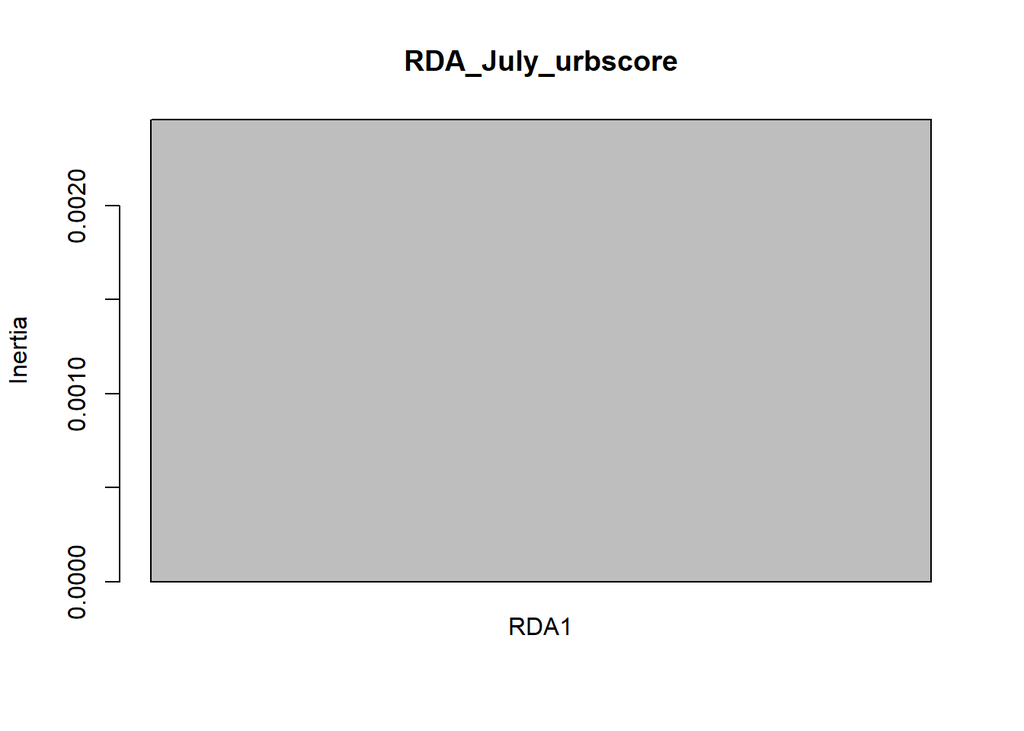

```r
screeplot(RDA_July_urbscore)
```

```r
### Just urban sites
#### herbivores ~ City_dist
RDA_July.urb <- rda(herb2020_July_urb.hel ~ City_dist + Transect_ID,
                              data = herb2020_July_urb.env )
summary(RDA_July.urb)
```

```
##
## Call:
## rda(formula = herb2020_July_urb.hel ~ City_dist + Transect_ID,      data = herb2020_July_urb.env)
##
## Partitioning of variance:
##                Inertia Proportion
## Total         0.114384    1.00000
## Constrained   0.003875    0.03388
## Unconstrained 0.110508    0.96612
##
## Eigenvalues, and their contribution to the variance
##
## Importance of components:
##                           RDA1      RDA2     PC1     PC2      PC3      PC4
## Eigenvalue            0.002982 0.0008939 0.07641 0.01089 0.007791 0.007527
## Proportion Explained  0.026066 0.0078145 0.66801 0.09522 0.068114 0.065803
## Cumulative Proportion 0.026066 0.0338804 0.70189 0.79711 0.865222 0.931025
##                            PC5      PC6      PC7       PC8       PC9      PC10
## Eigenvalue            0.003159 0.001796 0.001349 0.0008303 0.0005043 0.0002509
## Proportion Explained  0.027618 0.015704 0.011792 0.0072586 0.0044089 0.0021936
## Cumulative Proportion 0.958643 0.974347 0.986139 0.9933975 0.9978064 1.0000000
##
## Accumulated constrained eigenvalues
## Importance of components:
##                           RDA1      RDA2
## Eigenvalue            0.002982 0.0008939
## Proportion Explained  0.769351 0.2306492
## Cumulative Proportion 0.769351 1.0000000
##
## Scaling 2 for species and site scores
## * Species are scaled proportional to eigenvalues
## * Sites are unscaled: weighted dispersion equal on all dimensions
## * General scaling constant of scores:  1.404303
##
##
## Species scores
##
##                                     RDA1     RDA2        PC1       PC2
## mean_Monarch_Quantity_Past      0.000000  0.00000  0.0000000  0.000000
## mean_Monarch_Quantity_Observed -0.058030 -0.02463 -0.1347070 -0.024061
```

[output cut: 100 more lines]

```
## row35  0.048017  0.22847  0.089259 -0.52396  0.296656 -0.1186069
##
##
## Biplot scores for constraining variables
##
##                    RDA1    RDA2 PC1 PC2 PC3 PC4
## City_dist        0.9749 -0.2226   0   0   0   0
## Transect_IDSouth 0.3537  0.9354   0   0   0   0
##
##
## Centroids for factor constraints
##
##                      RDA1    RDA2 PC1 PC2 PC3 PC4
## Transect_IDNorth -0.08639 -0.2285   0   0   0   0
## Transect_IDSouth  0.08159  0.2158   0   0   0   0
```

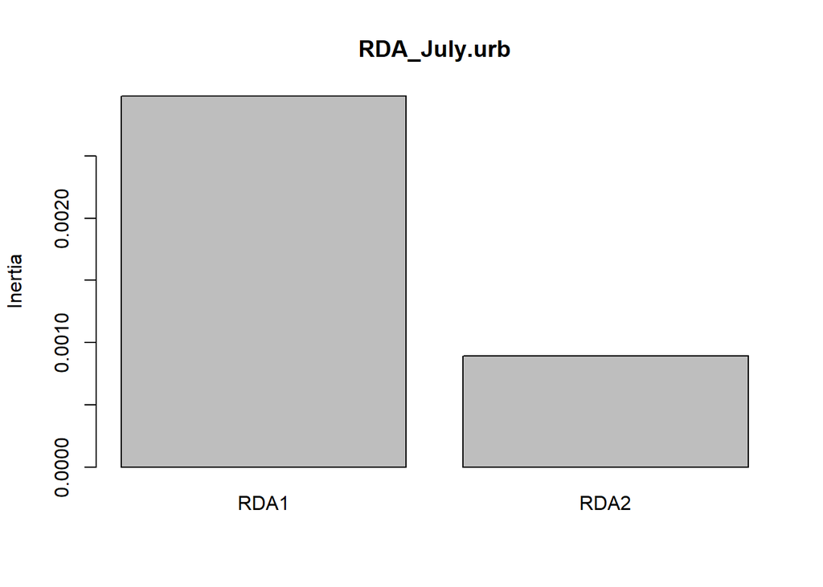

```r
screeplot(RDA_July.urb)
```

```r
#### herbivores ~ Urb_score
RDA_July_urbscore.urb <- rda(herb2020_July_urb.hel ~ Urb_score + Transect_ID,
                              data = herb2020_July_urb.env )
summary(RDA_July_urbscore.urb)
```

```
##
## Call:
## rda(formula = herb2020_July_urb.hel ~ Urb_score + Transect_ID,      data = herb2020_July_urb.env)
##
## Partitioning of variance:
##                Inertia Proportion
## Total         0.114384    1.00000
## Constrained   0.003141    0.02746
## Unconstrained 0.111243    0.97254
##
## Eigenvalues, and their contribution to the variance
##
## Importance of components:
##                           RDA1      RDA2     PC1     PC2      PC3      PC4
## Eigenvalue            0.002494 0.0006463 0.07786 0.01014 0.007819 0.007522
## Proportion Explained  0.021807 0.0056504 0.68072 0.08862 0.068359 0.065764
## Cumulative Proportion 0.021807 0.0274569 0.70818 0.79680 0.865161 0.930925
##                            PC5      PC6      PC7       PC8       PC9     PC10
## Eigenvalue            0.003117 0.001803 0.001335 0.0008326 0.0005316 0.000282
## Proportion Explained  0.027248 0.015765 0.011669 0.0072793 0.0046476 0.002465
## Cumulative Proportion 0.958173 0.973939 0.985608 0.9928873 0.9975348 1.000000
##
## Accumulated constrained eigenvalues
## Importance of components:
##                           RDA1      RDA2
## Eigenvalue            0.002494 0.0006463
## Proportion Explained  0.794210 0.2057904
## Cumulative Proportion 0.794210 1.0000000
##
## Scaling 2 for species and site scores
## * Species are scaled proportional to eigenvalues
## * Sites are unscaled: weighted dispersion equal on all dimensions
## * General scaling constant of scores:  1.404303
##
##
## Species scores
##
##                                      RDA1       RDA2        PC1       PC2
## mean_Monarch_Quantity_Past      0.0000000  0.0000000  0.000e+00  0.000000
## mean_Monarch_Quantity_Observed  0.0085067  0.0459251 -1.436e-01 -0.020163
```

[output cut: 100 more lines]

```
## row35  0.101712 -0.33366  0.107573 -0.596554  0.38276 -0.031063
##
##
## Biplot scores for constraining variables
##
##                     RDA1    RDA2 PC1 PC2 PC3 PC4
## Urb_score         0.8931 -0.4498   0   0   0   0
## Transect_IDSouth -0.5247 -0.8513   0   0   0   0
##
##
## Centroids for factor constraints
##
##                     RDA1    RDA2 PC1 PC2 PC3 PC4
## Transect_IDNorth  0.1282  0.2079   0   0   0   0
## Transect_IDSouth -0.1210 -0.1964   0   0   0   0
```

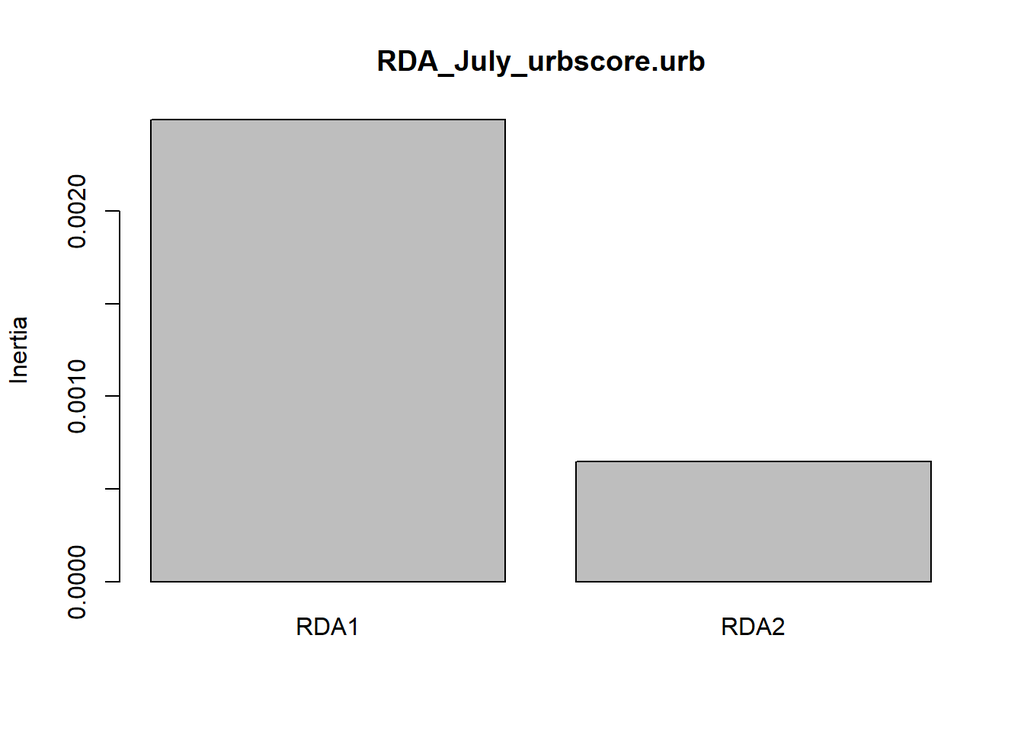

```r
screeplot(RDA_July_urbscore.urb)
```

#### 2.3.1.2 August

```r
### All sites
#### herbivores ~ City_dist
RDA_Aug <- rda(herb2020_Aug.hel ~ City_dist,
                              data=herb2020_Aug.env )
summary(RDA_Aug)
```

```
##
## Call:
## rda(formula = herb2020_Aug.hel ~ City_dist, data = herb2020_Aug.env)
##
## Partitioning of variance:
##                Inertia Proportion
## Total         0.191987     1.0000
## Constrained   0.005472     0.0285
## Unconstrained 0.186515     0.9715
##
## Eigenvalues, and their contribution to the variance
##
## Importance of components:
##                           RDA1     PC1     PC2     PC3      PC4      PC5
## Eigenvalue            0.005472 0.08587 0.04941 0.02619 0.006816 0.006362
## Proportion Explained  0.028504 0.44729 0.25738 0.13643 0.035500 0.033135
## Cumulative Proportion 0.028504 0.47580 0.73317 0.86961 0.905106 0.938241
##                            PC6      PC7      PC8       PC9      PC10      PC11
## Eigenvalue            0.004078 0.003157 0.002303 0.0009559 0.0007522 0.0006107
## Proportion Explained  0.021243 0.016443 0.011995 0.0049791 0.0039180 0.0031809
## Cumulative Proportion 0.959484 0.975927 0.987922 0.9929011 0.9968191 1.0000000
##
## Accumulated constrained eigenvalues
## Importance of components:
##                           RDA1
## Eigenvalue            0.005472
## Proportion Explained  1.000000
## Cumulative Proportion 1.000000
##
## Scaling 2 for species and site scores
## * Species are scaled proportional to eigenvalues
## * Sites are unscaled: weighted dispersion equal on all dimensions
## * General scaling constant of scores:  1.760194
##
##
## Species scores
##
##                                     RDA1       PC1       PC2       PC3
## mean_Monarch_Quantity_Past     -0.015320  0.003507 -0.012787  0.012494
## mean_Monarch_Quantity_Observed  0.002316 -0.117455  0.079751 -0.156048
```

[output cut: 124 more lines]

```
## row43 -0.122017 -0.19815  0.097227 -0.042561  0.233174  0.19980
## row44 -0.079368  0.20432  0.241002  0.083253 -0.134314  0.18934
## row45 -0.013666 -0.11833  0.128688 -0.185688  0.066005 -0.07844
## row46  0.007873 -0.11787 -0.117521  0.213190 -0.017178 -0.26172
## row47  0.008063 -0.20969  0.112170 -0.082701  0.413196  0.10792
## row48  0.008462 -0.18374  0.268613  0.240054 -0.319791  0.30608
## row49 -0.052541 -0.16776  0.088423  0.308343 -0.052815 -0.68594
## row50 -0.101653 -0.20851  0.027525 -0.230596  0.271356  0.16300
## row51 -0.145885 -0.13756 -0.128085  0.282868  0.015061 -0.11829
##
##
## Biplot scores for constraining variables
##
##           RDA1 PC1 PC2 PC3 PC4 PC5
## City_dist    1   0   0   0   0   0
```

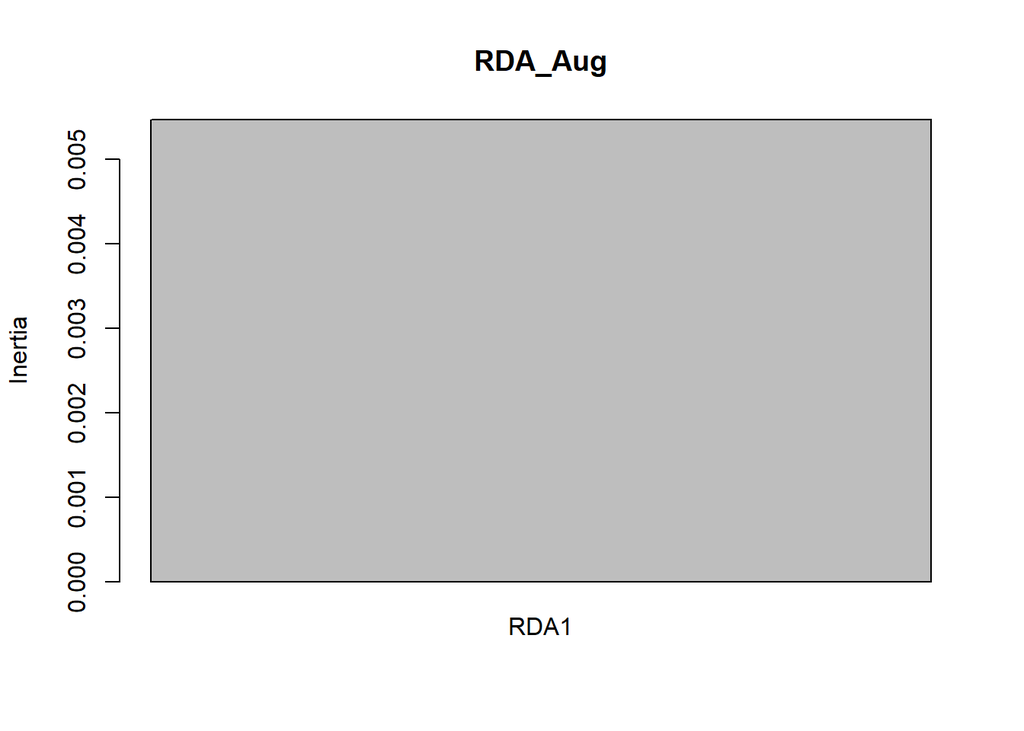

```r
screeplot(RDA_Aug)
```

```r
#### herbivores ~ Urb_score
RDA_Aug_urbscore <- rda(herb2020_Aug.hel ~ Urb_score,
                              data = herb2020_Aug.env )
summary(RDA_Aug_urbscore)
```

```
##
## Call:
## rda(formula = herb2020_Aug.hel ~ Urb_score, data = herb2020_Aug.env)
##
## Partitioning of variance:
##                Inertia Proportion
## Total         0.191987     1.0000
## Constrained   0.007852     0.0409
## Unconstrained 0.184135     0.9591
##
## Eigenvalues, and their contribution to the variance
##
## Importance of components:
##                           RDA1     PC1     PC2     PC3      PC4      PC5
## Eigenvalue            0.007852 0.08202 0.05061 0.02652 0.006749 0.006427
## Proportion Explained  0.040898 0.42719 0.26360 0.13812 0.035154 0.033476
## Cumulative Proportion 0.040898 0.46809 0.73169 0.86980 0.904958 0.938434
##                            PC6      PC7      PC8       PC9      PC10      PC11
## Eigenvalue            0.004063 0.003166 0.002284 0.0009646 0.0007162 0.0006261
## Proportion Explained  0.021162 0.016488 0.011899 0.0050243 0.0037307 0.0032612
## Cumulative Proportion 0.959596 0.976085 0.987984 0.9930081 0.9967388 1.0000000
##
## Accumulated constrained eigenvalues
## Importance of components:
##                           RDA1
## Eigenvalue            0.007852
## Proportion Explained  1.000000
## Cumulative Proportion 1.000000
##
## Scaling 2 for species and site scores
## * Species are scaled proportional to eigenvalues
## * Sites are unscaled: weighted dispersion equal on all dimensions
## * General scaling constant of scores:  1.760194
##
##
## Species scores
##
##                                     RDA1       PC1       PC2       PC3
## mean_Monarch_Quantity_Past      0.013140  0.004630 -0.011828  0.010946
## mean_Monarch_Quantity_Observed  0.001186 -0.117503  0.086461 -0.151444
```

[output cut: 124 more lines]

```
## row43  0.0649440 -0.197295  0.125412 -0.0525795  0.26485  0.190849
## row44  0.1072449  0.232427  0.224403  0.0913828 -0.13527  0.192053
## row45  0.3835279 -0.023536  0.058338 -0.1488733 -0.02618 -0.124032
## row46  0.1206412 -0.094339 -0.142680  0.2190903 -0.05752 -0.266512
## row47  0.1504611 -0.172261  0.089823 -0.0670805  0.39722  0.060673
## row48  0.1675397 -0.139745  0.232666  0.2626942 -0.32183  0.312291
## row49  0.3046457 -0.101975  0.037513  0.3296152 -0.15025 -0.691536
## row50  0.2237092 -0.167844  0.022182 -0.2260504  0.25999  0.133915
## row51  0.2716711 -0.095192 -0.145178  0.2787553 -0.02043 -0.116952
##
##
## Biplot scores for constraining variables
##
##           RDA1 PC1 PC2 PC3 PC4 PC5
## Urb_score    1   0   0   0   0   0
```

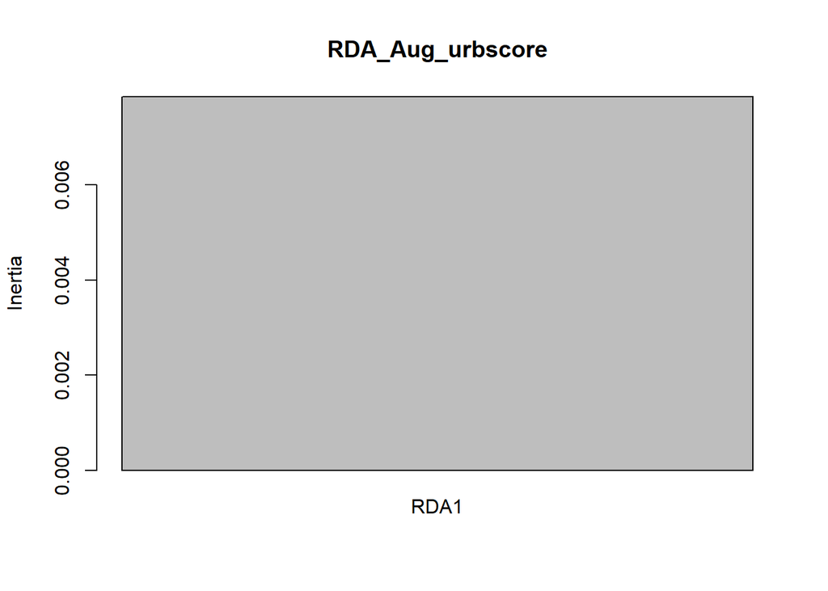

```r
screeplot(RDA_Aug_urbscore)
```

```r
### Just urban sites
#### herbivores ~ City_dist
RDA_Aug.urb <- rda(herb2020_Aug_urb.hel ~ City_dist + Transect_ID,
                              data = herb2020_Aug_urb.env )
summary(RDA_Aug.urb)
```

```
##
## Call:
## rda(formula = herb2020_Aug_urb.hel ~ City_dist + Transect_ID,      data = herb2020_Aug_urb.env)
##
## Partitioning of variance:
##               Inertia Proportion
## Total         0.16824    1.00000
## Constrained   0.00884    0.05255
## Unconstrained 0.15940    0.94745
##
## Eigenvalues, and their contribution to the variance
##
## Importance of components:
##                           RDA1     RDA2     PC1     PC2    PC3      PC4
## Eigenvalue            0.005011 0.003829 0.09737 0.02483 0.0180 0.006644
## Proportion Explained  0.029788 0.022757 0.57875 0.14759 0.1070 0.039493
## Cumulative Proportion 0.029788 0.052545 0.63130 0.77889 0.8859 0.925376
##                            PC5     PC6      PC7      PC8       PC9      PC10
## Eigenvalue            0.003734 0.00340 0.001824 0.001397 0.0009579 0.0006986
## Proportion Explained  0.022196 0.02021 0.010839 0.008301 0.0056939 0.0041524
## Cumulative Proportion 0.947572 0.96778 0.978622 0.986924 0.9926178 0.9967701
##                            PC11
## Eigenvalue            0.0005434
## Proportion Explained  0.0032299
## Cumulative Proportion 1.0000000
##
## Accumulated constrained eigenvalues
## Importance of components:
##                           RDA1     RDA2
## Eigenvalue            0.005011 0.003829
## Proportion Explained  0.566904 0.433096
## Cumulative Proportion 0.566904 1.000000
##
## Scaling 2 for species and site scores
## * Species are scaled proportional to eigenvalues
## * Sites are unscaled: weighted dispersion equal on all dimensions
## * General scaling constant of scores:  1.546503
##
##
## Species scores
```

[output cut: 104 more lines]

```
## row35  0.2326 -0.109471 -0.177401  0.111871  0.43564  0.132071
##
##
## Biplot scores for constraining variables
##
##                    RDA1    RDA2 PC1 PC2 PC3 PC4
## City_dist        0.4101  0.9120   0   0   0   0
## Transect_IDSouth 0.9595 -0.2816   0   0   0   0
##
##
## Centroids for factor constraints
##
##                     RDA1     RDA2 PC1 PC2 PC3 PC4
## Transect_IDNorth -0.2581  0.07575   0   0   0   0
## Transect_IDSouth  0.2438 -0.07154   0   0   0   0
```

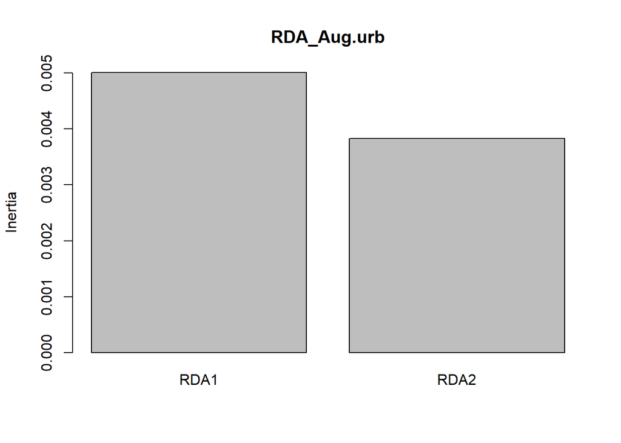

```r
screeplot(RDA_Aug.urb)
```

```r
#### herbivores ~ Urb_score
RDA_Aug_urbscore.urb <- rda(herb2020_Aug_urb.hel ~ Urb_score + Transect_ID,
                              data = herb2020_Aug_urb.env )
summary(RDA_Aug_urbscore.urb)
```

```
##
## Call:
## rda(formula = herb2020_Aug_urb.hel ~ Urb_score + Transect_ID,      data = herb2020_Aug_urb.env)
##
## Partitioning of variance:
##                Inertia Proportion
## Total         0.168238    1.00000
## Constrained   0.009104    0.05411
## Unconstrained 0.159134    0.94589
##
## Eigenvalues, and their contribution to the variance
##
## Importance of components:
##                           RDA1     RDA2     PC1     PC2     PC3      PC4
## Eigenvalue            0.006499 0.002605 0.09734 0.02527 0.01646 0.006554
## Proportion Explained  0.038628 0.015485 0.57857 0.15018 0.09786 0.038958
## Cumulative Proportion 0.038628 0.054113 0.63268 0.78287 0.88072 0.919679
##                           PC5      PC6      PC7      PC8       PC9      PC10
## Eigenvalue            0.00476 0.003481 0.001713 0.001341 0.0009611 0.0007144
## Proportion Explained  0.02829 0.020689 0.010183 0.007971 0.0057128 0.0042461
## Cumulative Proportion 0.94797 0.968662 0.978845 0.986816 0.9925289 0.9967750
##                            PC11
## Eigenvalue            0.0005426
## Proportion Explained  0.0032250
## Cumulative Proportion 1.0000000
##
## Accumulated constrained eigenvalues
## Importance of components:
##                           RDA1     RDA2
## Eigenvalue            0.006499 0.002605
## Proportion Explained  0.713844 0.286156
## Cumulative Proportion 0.713844 1.000000
##
## Scaling 2 for species and site scores
## * Species are scaled proportional to eigenvalues
## * Sites are unscaled: weighted dispersion equal on all dimensions
## * General scaling constant of scores:  1.546503
##
##
## Species scores
```

[output cut: 104 more lines]

```
## row35 -0.012165  0.383951 -0.12741  0.15125  0.36606  0.173116
##
##
## Biplot scores for constraining variables
##
##                     RDA1   RDA2 PC1 PC2 PC3 PC4
## Urb_score         0.7009 0.7132   0   0   0   0
## Transect_IDSouth -0.7707 0.6372   0   0   0   0
##
##
## Centroids for factor constraints
##
##                     RDA1    RDA2 PC1 PC2 PC3 PC4
## Transect_IDNorth  0.2073 -0.1714   0   0   0   0
## Transect_IDSouth -0.1958  0.1619   0   0   0   0
```

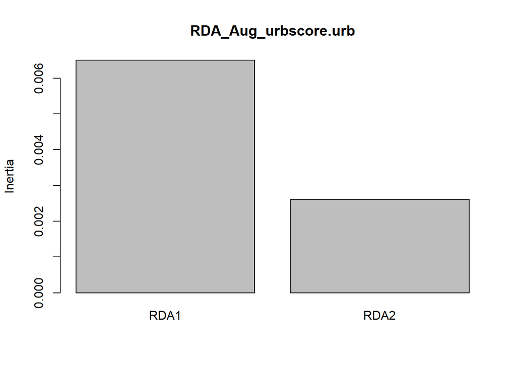

```r
screeplot(RDA_Aug_urbscore.urb)
```

### 2.3.2 RDA statistics

```r
RDA_list <- list(RDA_July,
                 RDA_July_urbscore,
                 RDA_July.urb,
                 RDA_July_urbscore.urb,
                 RDA_Aug,
                 RDA_Aug_urbscore,
                 RDA_Aug.urb,
                 RDA_Aug_urbscore.urb)

## canonical coefficients
canon_coeffs <- lapply(RDA_list, coef)
canon_coeffs
```

```
## [[1]]
##                RDA1
## City_dist 0.0081871
##
## [[2]]
##                 RDA1
## Urb_score 0.06765676
##
## [[3]]
##                        RDA1         RDA2
## City_dist        0.02114730 -0.007996933
## Transect_IDSouth 0.07598526  0.332839297
##
## [[4]]
##                        RDA1        RDA2
## Urb_score         0.1332336 -0.08211502
## Transect_IDSouth -0.1526747 -0.30317684
##
## [[5]]
##                RDA1
## City_dist 0.0081871
##
## [[6]]
##                 RDA1
## Urb_score 0.06765676
##
## [[7]]
##                         RDA1        RDA2
## City_dist        0.006366589  0.02169391
## Transect_IDSouth 0.311375834 -0.14000303
##
## [[8]]
##                         RDA1      RDA2
## Urb_score         0.09973053 0.1206146
## Transect_IDSouth -0.24209898 0.2379367
```

```r
# unadjusted R^2 retreived from the rda result
RsquareAdj(RDA_July              )$r.squared
```

```
## [1] 0.01756936
```

```r
RsquareAdj(RDA_July_urbscore     )$r.squared
```

```
## [1] 0.02095026
```

```r
RsquareAdj(RDA_July.urb          )$r.squared
```

```
## [1] 0.03388045
```

```r
RsquareAdj(RDA_July_urbscore.urb )$r.squared
```

```
## [1] 0.02745688
```

```r
RsquareAdj(RDA_Aug               )$r.squared
```

```
## [1] 0.02850384
```

```r
RsquareAdj(RDA_Aug_urbscore      )$r.squared
```

```
## [1] 0.04089813
```

```r
RsquareAdj(RDA_Aug.urb           )$r.squared
```

```
## [1] 0.05254517
```

```r
RsquareAdj(RDA_Aug_urbscore.urb  )$r.squared
```

```
## [1] 0.05411308
```

```r
# values very low... none above 0.06

# for (i in length(RDA_list)) {
#   print RsquareAdj(i)$r.squared
# }

# adjusted R^2
RsquareAdj(RDA_July              )$adj.r.squared
```

```
## [1] -0.002480242
```

```r
RsquareAdj(RDA_July_urbscore     )$adj.r.squared
```

```
## [1] 0.0009696557
```

```r
RsquareAdj(RDA_July.urb          )$adj.r.squared
```

```
## [1] -0.02650203
```

```r
RsquareAdj(RDA_July_urbscore.urb )$adj.r.squared
```

```
## [1] -0.03332706
```

```r
RsquareAdj(RDA_Aug               )$adj.r.squared
```

```
## [1] 0.008677383
```

```r
RsquareAdj(RDA_Aug_urbscore      )$adj.r.squared
```

```
## [1] 0.02132463
```

```r
RsquareAdj(RDA_Aug.urb           )$adj.r.squared
```

```
## [1] -0.006670752
```

```r
RsquareAdj(RDA_Aug_urbscore.urb  )$adj.r.squared
```

```
## [1] -0.005004856
```

```r
# values very low... none above 0.03
```

### 2.3.3 Plots

#### 2.3.3.1 Make plotting functions

```r
# Triplot: three different entities in the plot: sites, response variables and explanatory variables (arrowheads are on the explanatory variables)
## SCALING 1
makeRDAplot_scaling1 <- function(x) {
  plot(x, scaling=1, main="Triplot RDA matrix ~ env - scaling 1 - wa scores")
  spe.sc <- scores(x, choices=1:2, scaling=1, display="sp")
  arrows(0,0,spe.sc[,1], spe.sc[,2], length=0, lty=1, col='red')
}
# lapply(RDA_list, makeRDAplot_scaling1)

## SCALING 2
makeRDAplot_scaling2 <- function(x) {
  plot(x, main="Triplot RDA matrix ~ env - scaling 2 - wa scores")
  spe2.sc <- scores(x, choices=1:2, display="sp") # scores() choices= indicates which axes are to be selected, make sure to specify the scaling if its different than 2
  arrows(0,0,spe2.sc[,1], spe2.sc[,2], length=0, lty=1, col='red')
}
# lapply(RDA_list, makeRDAplot_scaling2)
```

**Scaling 1 vs Scaling 2:**

- Scaling 1- distance biplot (object focused): distance between objects are eudlidean distances (objects closer together have similar variable values), angles between vectors of response variables are meaningless. Angles between vectors of response variables and explanatory variables reflect linear correlation.
- Scaling 2- correlation biplot (response variable focused): distances between objects are not approximate Euclidean distances. Angles between all vectors reflect linear correlation.

*Taken directly from [this site](https://fukamilab.github.io/BIO202/06-B-constrained-ordination.html)*

#### 2.3.3.2 July

##### 2.3.3.2.1 All sites

###### 2.3.3.2.1.1 Environmental var: Distance from city center

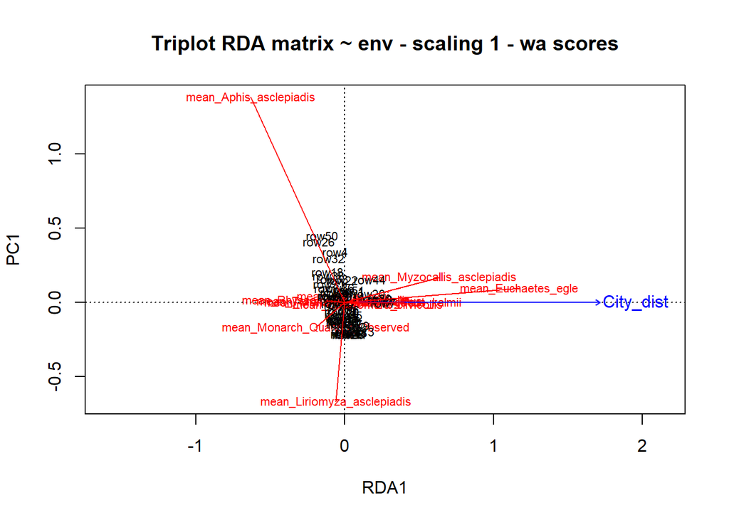

```r
# Scaling 1
makeRDAplot_scaling1(RDA_July)
```

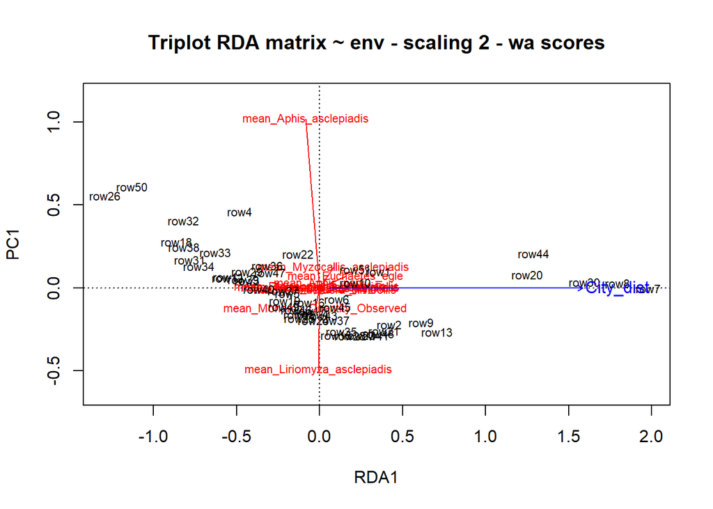

```r
# Scaling 2
makeRDAplot_scaling2(RDA_July)
```

###### 2.3.3.2.1.2 Environmental var: Urbanization score

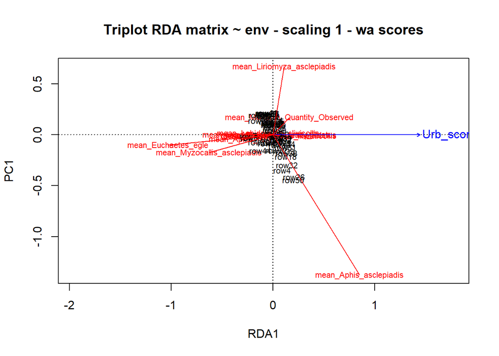

```r
# Scaling 1
makeRDAplot_scaling1(RDA_July_urbscore)
```

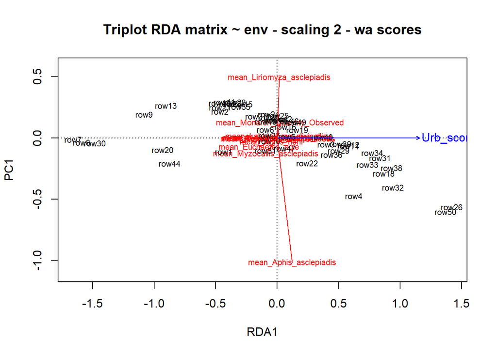

```r
# Scaling 2
makeRDAplot_scaling2(RDA_July_urbscore)
```

##### 2.3.3.2.2 Urban sites

###### 2.3.3.2.2.1 Environmental var: Distance from city center

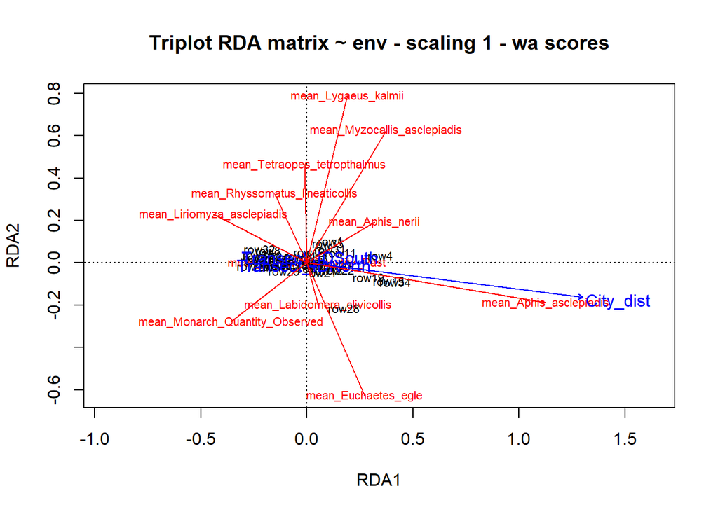

```r
# Scaling 1
makeRDAplot_scaling1(RDA_July.urb)
```

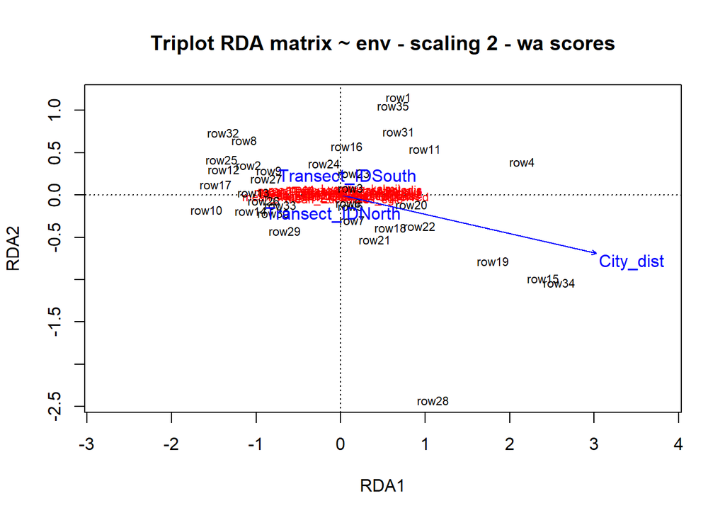

```r
# Scaling 2
makeRDAplot_scaling2(RDA_July.urb)
```

###### 2.3.3.2.2.2 Environmental var: Urbanization score

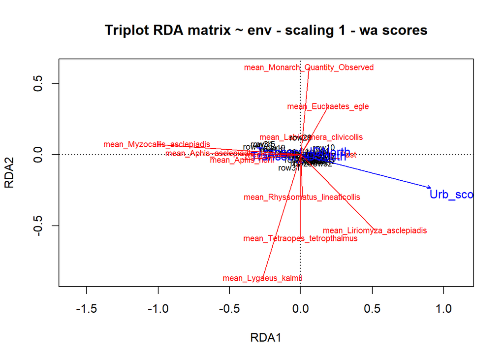

```r
# Scaling 1
makeRDAplot_scaling1(RDA_July_urbscore.urb)
```

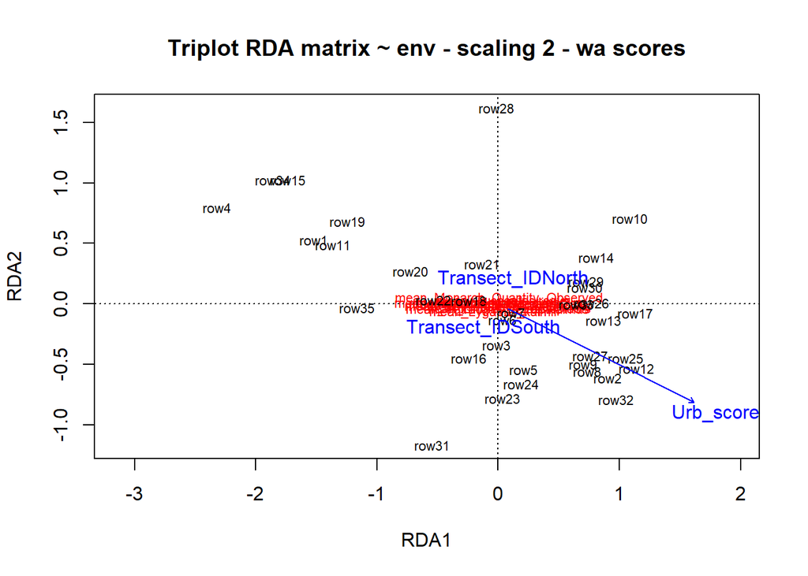

```r
# Scaling 2
makeRDAplot_scaling2(RDA_July_urbscore.urb)
```

#### 2.3.3.3 Aug

##### 2.3.3.3.1 All sites

###### 2.3.3.3.1.1 Environmental var: Distance from city center

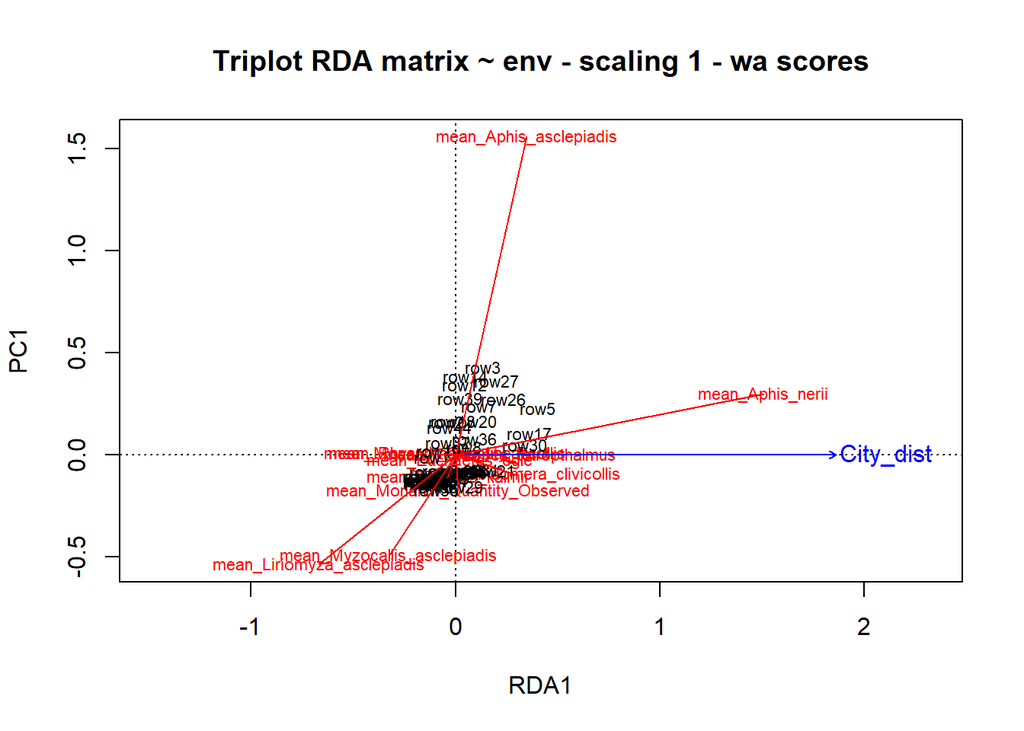

```r
# Scaling 1
makeRDAplot_scaling1(RDA_Aug)
```

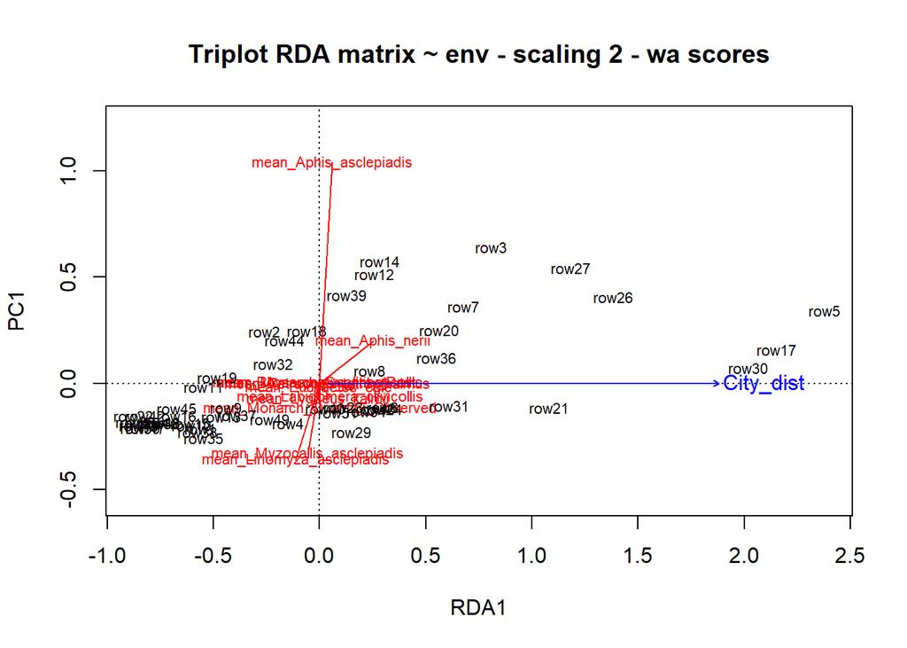

```r
# Scaling 2
makeRDAplot_scaling2(RDA_Aug)
```

###### 2.3.3.3.1.2 Environmental var: Urbanization score

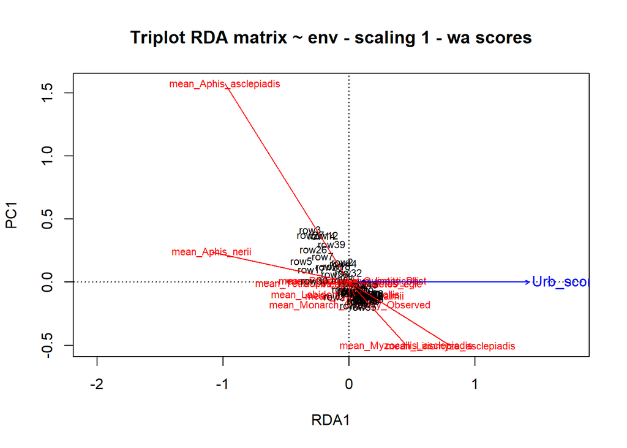

```r
# Scaling 1
makeRDAplot_scaling1(RDA_Aug_urbscore)
```

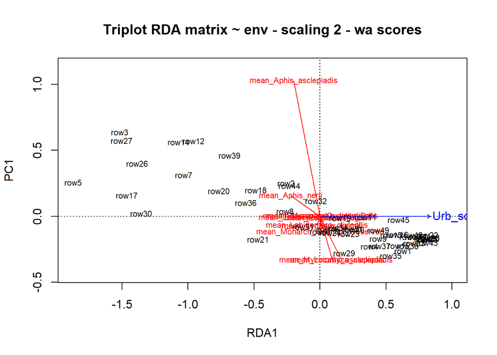

```r
# Scaling 2
makeRDAplot_scaling2(RDA_Aug_urbscore)
```

##### 2.3.3.3.2 Urban sites

###### 2.3.3.3.2.1 Environmental var: Distance from city center

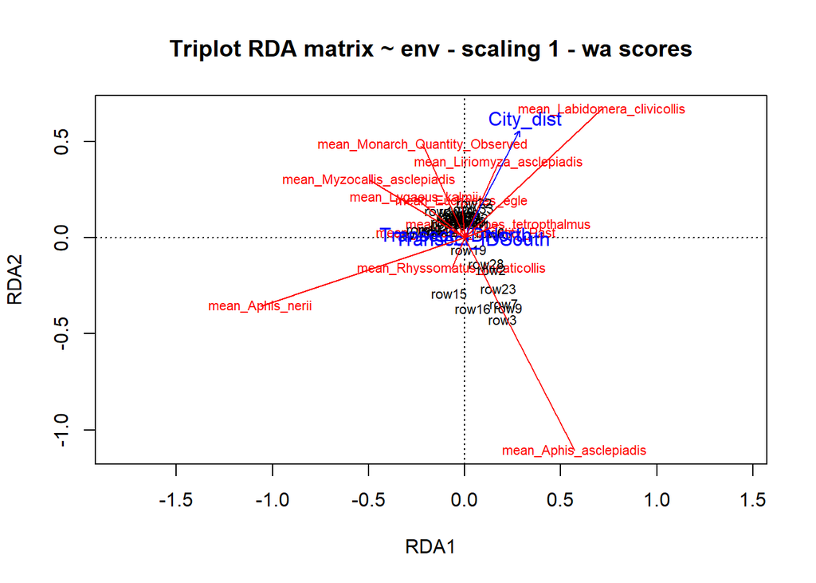

```r
# Scaling 1
makeRDAplot_scaling1(RDA_Aug.urb)
```

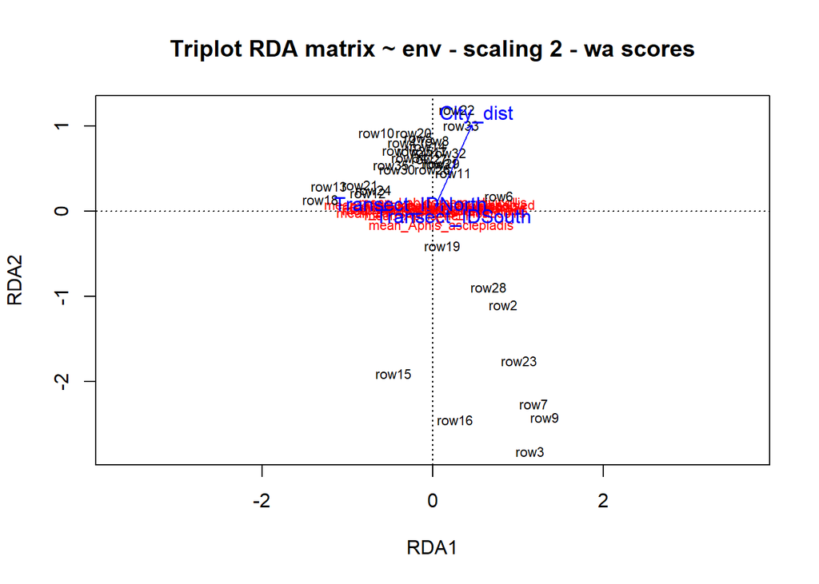

```r
# Scaling 2
makeRDAplot_scaling2(RDA_Aug.urb)
```

###### 2.3.3.3.2.2 Environmental var: Urbanization score

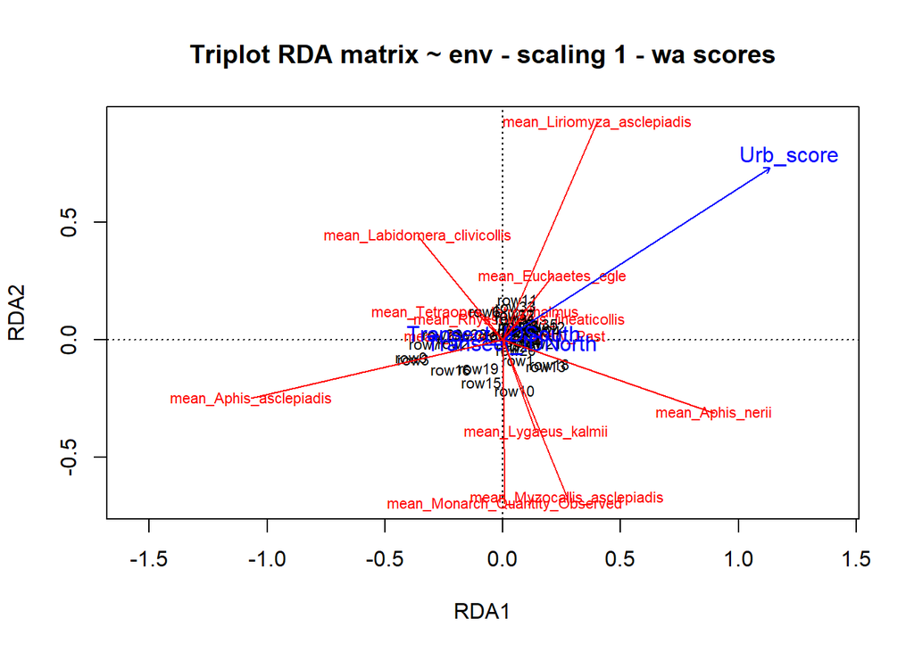

```r
# Scaling 1
makeRDAplot_scaling1(RDA_Aug_urbscore.urb)
```

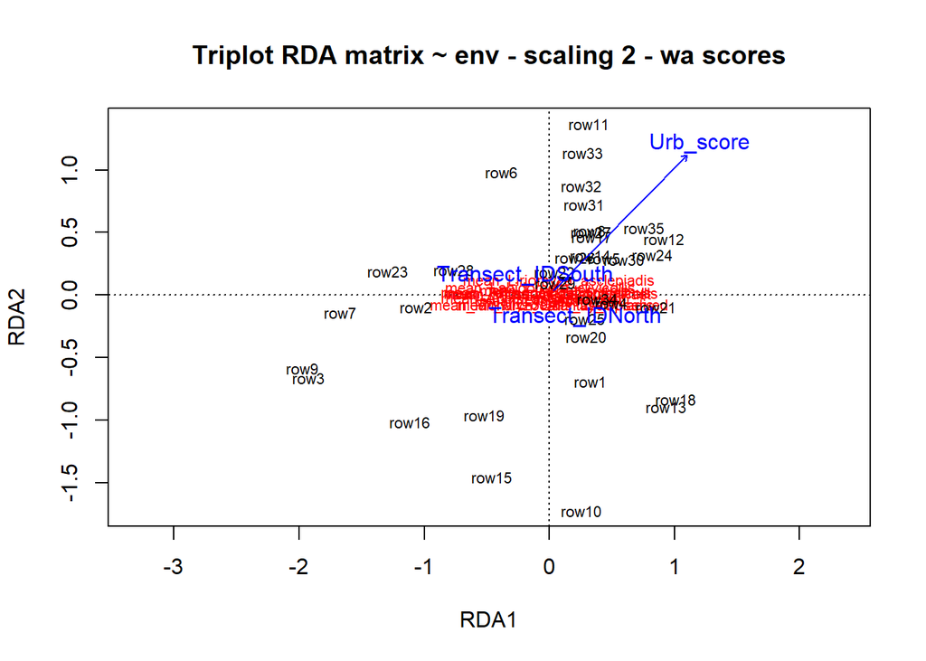

```r
# Scaling 2
makeRDAplot_scaling2(RDA_Aug_urbscore.urb)
```